# Prepare models predicting bulk from pseudobulk

Stephanie J. Spielman

2025-12-03

This goal of this notebook is to build models predicting bulk from pseudobulk for all projects and assess their fits. We build and assess the following random effects models for each project:

- `fit_plain`: `bulk ~ pseudobulk`
- `fit_additive`: `bulk ~ pseudobulk + (1|sample_id)`
- `fit_interaction`: `bulk ~ pseudobulk + (1|sample_id) + (1|sample_id:pseudobulk)`

In addition, the notebook parameter `expr_threshold` determines how genes are filtered from the data before modeling: Only genes which are expressed in greater than the proportion `expr_threshold` of samples, averaged across bulk and pseudobulk modalities, are retained. To turn off filtering, use a negative value.

In this notebook, the `expr_threshold` parameter is 0.25.

## Setup

```r
renv::load()

library(lme4)
library(ggplot2)
theme_set(theme_bw())
options(readr.show_col_types = FALSE)
```

Define a vector of low-quality samples that we want to exclude from analysis.

```r
# As identified in https://github.com/AlexsLemonade/scpca-paper-figures/issues/135
exclude_samples <- c(
  "SCPCS000003",
  "SCPCS000030",
  "SCPCS000040",
  "SCPCS000178",
  "SCPCS000191",
  "SCPCS000197",
  "SCPCS000203",
  "SCPCS000608"
)
```

### Paths

```r
analysis_dir <- here::here("analysis", "pseudobulk-bulk-prediction")
data_dir <- file.path(analysis_dir, "data")
output_dir <- file.path(analysis_dir, "results", "models")
fs::dir_create(output_dir)
```

Define files to read in:

```r
pseudobulk_files <- list.files(
  path = file.path(data_dir, "pseudobulk"),
  full.names = TRUE,
  pattern = "_pseudobulk\\.tsv$"
)
pseudobulk_names <- stringr::str_split_i(basename(pseudobulk_files), pattern = "_", i = 1)
names(pseudobulk_files) <- pseudobulk_names

bulk_counts_file <- file.path(data_dir, "normalized-bulk-counts.rds")
bulk_counts <- readr::read_rds(bulk_counts_file)

# Make sure we have the same projects, in the same order
stopifnot(
  all.equal(names(pseudobulk_files), names(bulk_counts))
)

# also the tables with fraction expressed
bulk_frac_expr_df <- readr::read_tsv(
  file.path(data_dir, "fraction-expressed-bulk.tsv")
) |>
  dplyr::rename(bulk_frac_expressed = frac_samples_expressed)

named_projects <- purrr::set_names(pseudobulk_names, pseudobulk_names)
expressed_df <- named_projects |>
  purrr::map(
    \(project_id) {
      readr::read_tsv(
        file.path(data_dir, glue::glue("{project_id}_fraction-expressed-single-cell.tsv"))
      )
    }
  ) |>
  purrr::list_rbind(names_to = "project_id") |>
  dplyr::rename(pseudobulk_frac_expressed = frac_samples_expressed) |>
  dplyr::full_join(bulk_frac_expr_df, by = c("project_id", "ensembl_id"))
```

### Functions

This chunk defines a helper function to read and combine bulk and pseudobulk datasets for a single project.

```r
prepare_data <- function(pseudo_file, bulk_df, id, exclude_samples, expressed_df) {

  # determine genes to keep
  keep_genes <- expressed_df |>
    dplyr::rowwise() |>
    dplyr::filter(
      project_id == id,
      mean(c(pseudobulk_frac_expressed, bulk_frac_expressed)) > params$expr_threshold
    ) |>
    dplyr::pull(ensembl_id)

  stopifnot(
    "Filtering on the given expression threshold removes all genes from at least one project. Please choose a different threshold." =
      length(keep_genes) > 0
  )

  pseudo_df <- readr::read_tsv(pseudo_file, show_col_types = FALSE) |>
    dplyr::filter(
      expression_type == "pseudobulk_deseq",
      !(sample_id %in% exclude_samples),
      ensembl_id %in% keep_genes
    ) |>
    dplyr::select(ensembl_id, sample_id, pseudobulk = expression)

  # make names consistent with pseudo_df
  bulk_df <- bulk_df |>
    dplyr::filter(
      !(sample_id %in% exclude_samples),
      ensembl_id %in% keep_genes
    ) |>
    dplyr::rename(bulk = bulk_counts)

  # combine bulk and pseudobulk into a single data frame
  expr_df <- dplyr::inner_join(
    pseudo_df,
    bulk_df,
    by = c("ensembl_id", "sample_id")
  )
  return(expr_df)
}
```

This chunk defines several helper functions to support modeling.

```r
# Build and return three models for a given project, including:
# - no random effects (`fit_plain`)
# - additive effect for sample_id (`fit_additive`)
# - interaction effect for sample_id (`fit_interaction`)
# Return a list of model objects named accordingly
model_data <- function(project_df) {
  list(
    fit_plain = lm(bulk ~ pseudobulk, data = project_df),
    # we set REML = FALSE here for the next models to enable comparisons with fit_plain
    fit_additive = lmer(bulk ~ pseudobulk + (1|sample_id), data = project_df, REML = FALSE),
    fit_interaction = lmer(bulk ~ pseudobulk + (1|sample_id) + (1|sample_id:pseudobulk), data = project_df, REML = FALSE)
  )
}


# Extract AIC, BIC, and sigma from a fitted model object
# In addition, extract the `lme4` convergence code if relevant
# Return a data frame of all quantities
extract_fit <- function(fit, fit_name) {

  # Calculate sigma, which differs per model type, and extract convergence code from lmer
  if (fit_name == "fit_plain") {
    ########### lm #############
    code <- NA
    sigma <- summary(fit)$sigma
  } else {
    ########### lmer ##############
    # this value only exists if the model did not converge
    grab_conv_code <- purrr::safely(
      \(fit) fit@optinfo$conv$lme4$code
    )
    code <- grab_conv_code(fit)$result
    sigma <- unname(fit@devcomp$cmp["sigmaML"]) # use ML, not REML!
  }

  data.frame(
    fit_name = fit_name,
    conv_code = ifelse(is.null(code), 0, code),
    sigma = sigma,
    aic = AIC(fit),
    bic = BIC(fit)
  )

}


# Extract data frame of residuals and fitted values from a given model
extract_residuals <- function(fit) {
  data.frame(
    residuals = unname(resid(fit)),
    fitted_values = unname(fitted(fit))
  )
}
```

## Perform modeling

We’ll now read in all datasets and then build all models.

```r
project_df_list <- named_projects |>
  purrr::map(
  \(project_id) {
    prepare_data(
      pseudobulk_files[[project_id]],
      bulk_counts[[project_id]],
      project_id,
      exclude_samples = exclude_samples,
      expressed_df = expressed_df
    )
  }
)

all_models <- project_df_list |>
  purrr::map(model_data)
```

```
Warning in checkConv(attr(opt, "derivs"), opt$par, ctrl = control$checkConv, :
unable to evaluate scaled gradient
```

```
Warning in checkConv(attr(opt, "derivs"), opt$par, ctrl = control$checkConv, :
Model failed to converge: degenerate Hessian with 1 negative eigenvalues
```

```
Warning in checkConv(attr(opt, "derivs"), opt$par, ctrl = control$checkConv, :
Model failed to converge with max|grad| = 0.00381329 (tol = 0.002, component 1)
```

```r
# clean up
rm(bulk_counts)
```

As we see, there are some warnings that at least some of the random effects models did not converge.

### Fit statistics

Next, we want to look at some of the fit statistics, including whether the random effects models converged. In the `conv_code` column for these models, a negative value indicates the model did not converge and `0` indicates that it did.

```r
all_models |>
  purrr::map(
    \(model_list) {
      purrr::imap(model_list, extract_fit) |>
        purrr::list_rbind()
    }
  ) |>
  purrr::list_rbind(names_to = "project_id")
```

| project_id | fit_name | conv_code | sigma | aic | bic |
| --- | --- | --- | --- | --- | --- |
| SCPCP000001 | fit_plain | NA | 2.926537 | 2751535.5 | 2751569.2 |
| SCPCP000001 | fit_additive | 0 | 2.925738 | 2751287.8 | 2751332.7 |
| SCPCP000001 | fit_interaction | -3 | 1.748703 | 2733784.6 | 2733840.7 |
| SCPCP000002 | fit_plain | NA | 3.066683 | 2989178.9 | 2989212.7 |
| SCPCP000002 | fit_additive | 0 | 3.065673 | 2988851.4 | 2988896.5 |
| SCPCP000002 | fit_interaction | 0 | 1.659289 | 2968702.0 | 2968758.5 |
| SCPCP000006 | fit_plain | NA | 3.986167 | 7256388.9 | 7256425.2 |
| SCPCP000006 | fit_additive | 0 | 3.985715 | 7256177.5 | 7256225.8 |
| SCPCP000006 | fit_interaction | -3 | 1.996280 | 7225776.4 | 7225836.7 |
| SCPCP000009 | fit_plain | NA | 2.237344 | 721792.7 | 721822.7 |

[output cut: 5 more lines]

### Residual plots

Next we’ll look at the residual plots for each model to see if we can detect anything else there. We’ll use binning in these plots to get a sense of point density as well. For this, we collapse all points above the upper scale bound so that we can visualize smaller values in the binning.

```r
residuals_df <- all_models |>
  purrr::map(
    \(model_list) {
        purrr::map(model_list, extract_residuals) |>
          purrr::list_rbind(names_to = "model_name")
  }) |>
  purrr::list_rbind(names_to = "project_id") |>
  dplyr::mutate(
    model_name = forcats::fct_relevel(
      model_name, "fit_plain", "fit_additive", "fit_interaction"
    )
  )
```

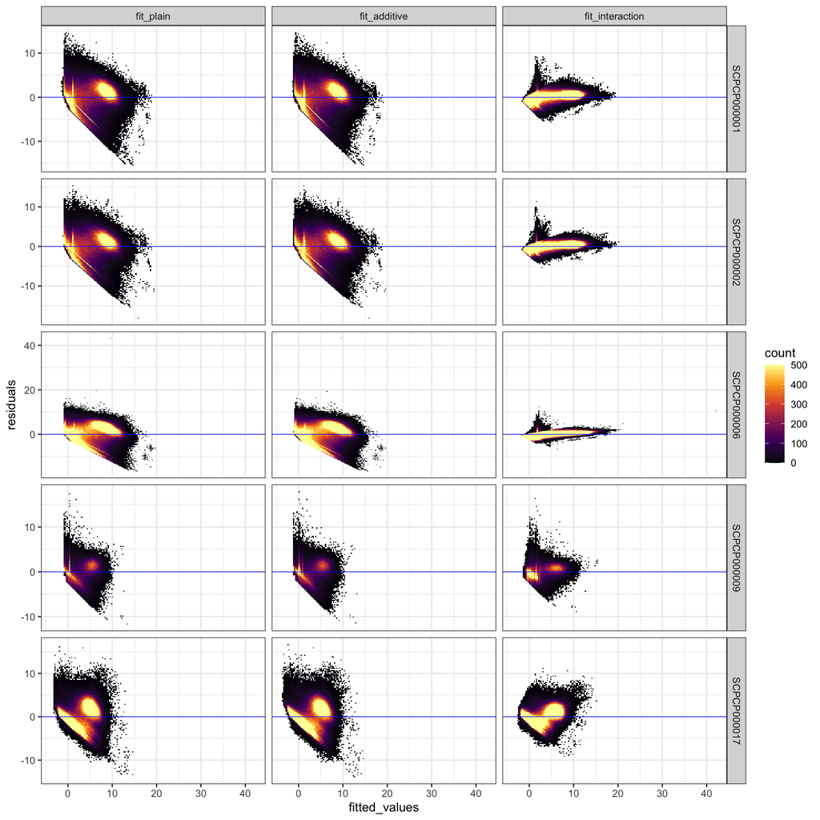

```r
ggplot(residuals_df) +
  aes(x = fitted_values, y = residuals) +
  geom_bin_2d(binwidth = 0.25) +
  scale_fill_viridis_c(limits = c(0, 500), oob = scales::squish, option = "inferno") +
  geom_hline(yintercept = 0, color = "blue", linewidth = 0.25) +
  facet_grid(
    cols = vars(model_name),
    rows = vars(project_id),
    scales = "free_y"
  )
```

## Export

We’ll export both the additive model objects as RDS files and the underlying data, including Ensembl IDs and residuals, as TSV files separately for each project.

```r
all_models |>
  purrr::iwalk(
    \(model_list, project_id) {

      threshold_str <- ifelse(params$expr_threshold < 0, "all-genes", glue::glue("threshold-{params$expr_threshold}"))

      # Export model to rds file
      fit <- model_list[["fit_additive"]]
      readr::write_rds(
        fit,
        file.path(
          output_dir,
          glue::glue("{project_id}_bulk-pseudobulk-model_{threshold_str}.rds")
        )
      )

      # Prepare and export data to tsv file
      output_data <- project_df_list[[project_id]] |>
        dplyr::mutate(residual = resid(fit)) |>
        readr::write_tsv(
          file.path(
            output_dir,
            glue::glue("{project_id}_bulk-pseudobulk-data_{threshold_str}.tsv")
          )
        )
  }
)
```